# White Wine Dataset - Explore and Summarize Data by James Tooles

The ‘chlorides’ feature looks normally distributed around the median of 0.043, with a mean of 0.046 but, the data does have a long tail to the right that makes up a small portion of the overall wines. It would make sense for wines to have the smallest amount of salt possible due to wines not being known for their high salinity.

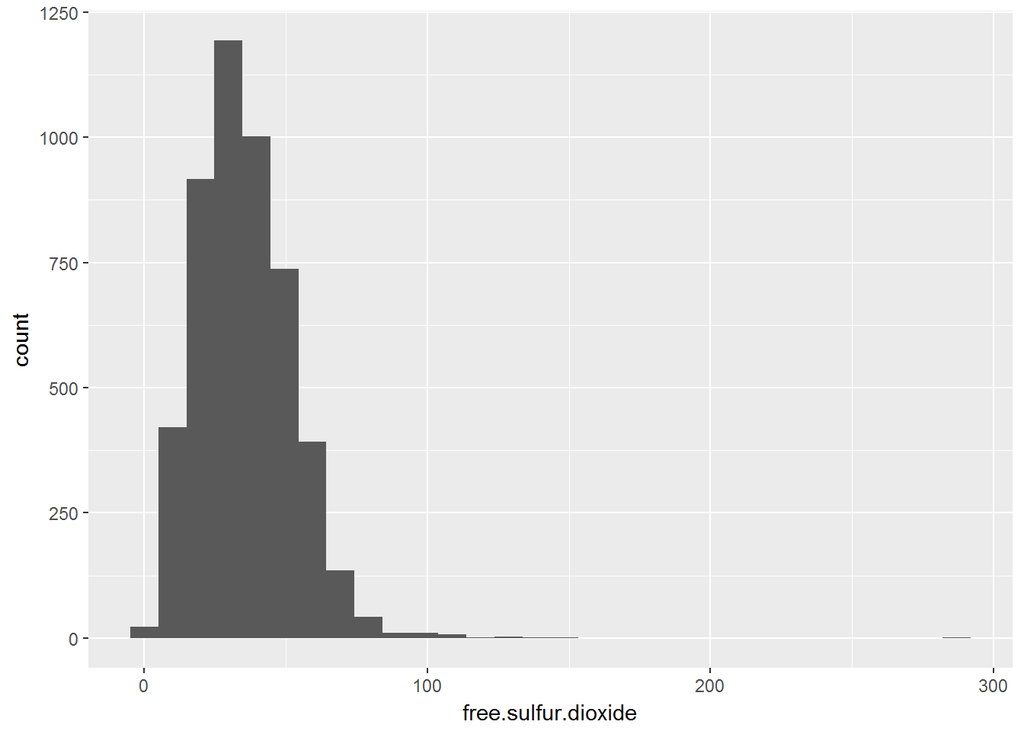

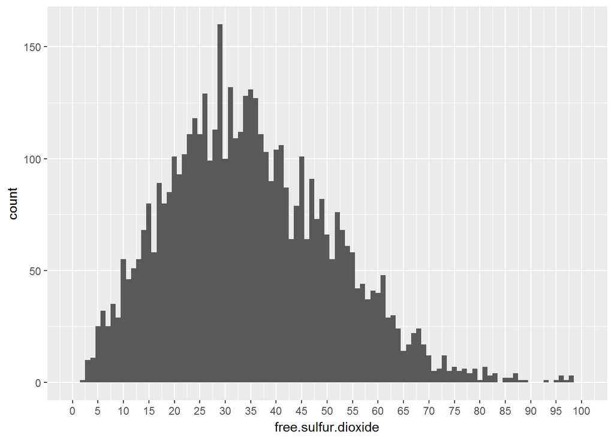

```
##    Min. 1st Qu.  Median    Mean 3rd Qu.    Max.
##    2.00   23.00   34.00   35.31   46.00  289.00
```

From the dataset documentation:

- free sulfur dioxide (mg / dm^3): the free form of SO2 exists in equilibrium between molecular SO2 (as a dissolved gas) and bisulfite ion; it prevents microbial growth and the oxidation of wine

The ‘free.sulfur.dioxide’ feature looks normally distributed around the median 34.00, with a mean of 35.31. The histogram has a long tail to the right, showing outliers with extreme free sulfur dioxide levels. Based on the description of from the dataset documentation, this feature acts as a preservative for the wine.

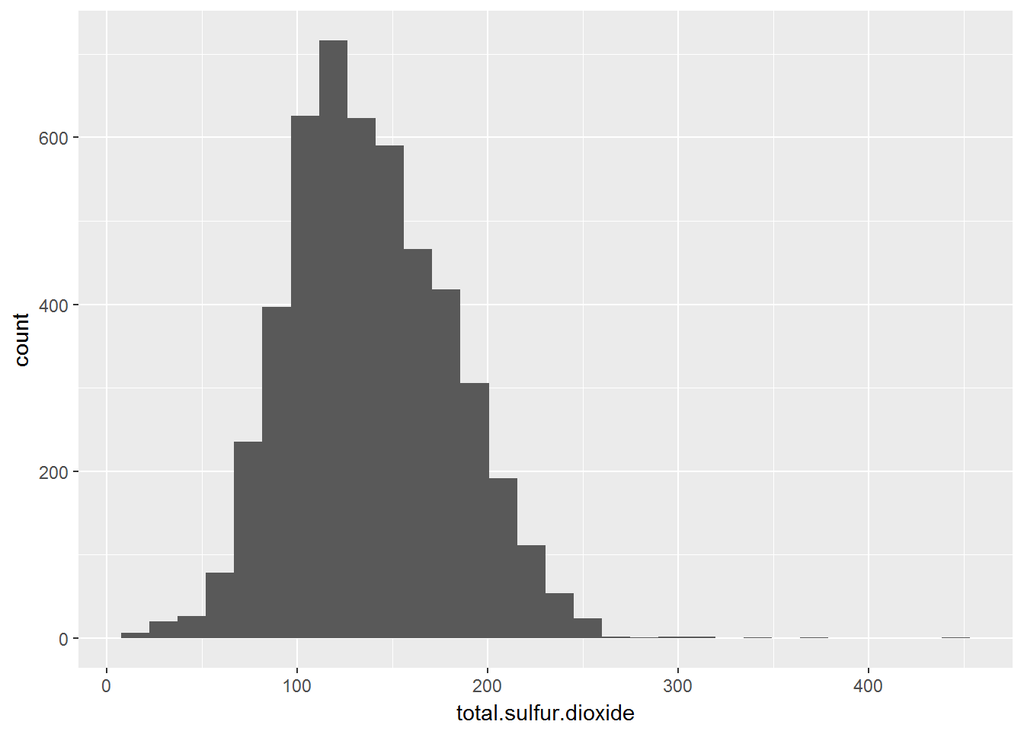

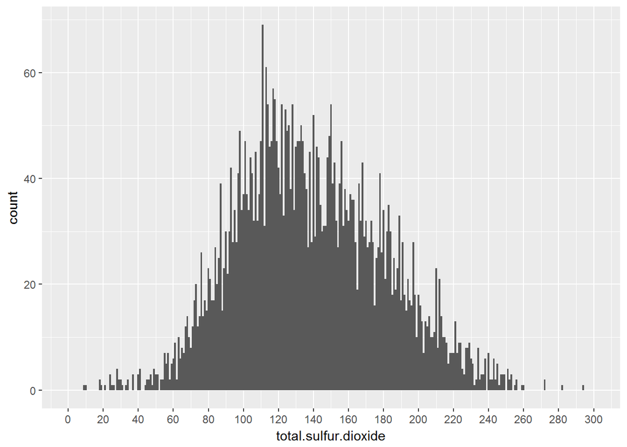

```
##    Min. 1st Qu.  Median    Mean 3rd Qu.    Max.
##     9.0   108.0   134.0   138.4   167.0   440.0
```

From the dataset documentation:

- total sulfur dioxide (mg / dm^3): amount of free and bound forms of S02; in low concentrations, SO2 is mostly undetectable in wine, but at free SO2 concentrations over 50 ppm, SO2 becomes evident in the nose and taste of wine